# PJ_ANGSD

JingjingQi

2/13/2020

### Introduction

rRNAs constitute >90% of the total RNA mass within cells [1–2], RNA-seq library preparation methods may affect the outcome and interpretation of metatranscriptomic data. Methods for either enriching for mRNAs or depletion of rRNAs are used to enhance the sensitivity of RNA-seq to rare mRNA transcripts. poly(A) enrichment strategies fails to capture non-poly(A) transcripts or partially degraded mRNAs. Alternative strategies that address this bias are based on the specific removal of rRNAs [5–7]. These strategies have the added potential advantage of capturing non-ribosomal transcripts that lack polyadenylated tails.

### Samples and RNA Preparation

RNA from eight human mammary epithelial cell (HMEC) lines obtained from American Type Culture Collection (ATCC) was extracted from mid log phase cultures at low passage (P1 or P2) using TRIzol kit (Invitrogen), each with high quality RNA (RIN numbers all >9.7). These cell lines were derived from 8 different individuals (biological replicates), of which 4 were with involuted and 4 were with non-involuted epithelial cells, the phenotype associated with an increased breast cancer risk. Metadata is summarized in table1.

*Table 1. Experiment design metadata*

| Run | involution | rna_preparation | source |
| --- | --- | --- | --- |
| SRR900275 | Yes | Illumina PolyA | DHF168 Yes |
| SRR900276 | No | Illumina PolyA | BSO19B No |
| SRR900277 | Yes | Illumina PolyA | BSO28 Yes |
| SRR900278 | No | Illumina PolyA | BSO29 No |
| SRR900279 | Yes | Illumina PolyA | BSO30 Yes |
| SRR900280 | No | Illumina PolyA | BSO32N No |
| SRR900281 | No | Illumina PolyA | BSO36 No |
| SRR900282 | Yes | Illumina PolyA | BSO37 Yes |
| SRR900283 | Yes | NuGEN Ovation | DHF168 Yes |
| SRR900284 | No | NuGEN Ovation | BSO19B No |
| SRR900285 | Yes | NuGEN Ovation | BSO28 Yes |
| SRR900286 | No | NuGEN Ovation | BSO29 No |
| SRR900287 | Yes | NuGEN Ovation | BSO30 Yes |
| SRR900288 | No | NuGEN Ovation | BSO32N No |
| SRR900289 | No | NuGEN Ovation | BSO36 No |
| SRR900290 | Yes | NuGEN Ovation | BSO37 Yes |

### RNA Sequencing

The paired-end sequencing at 51 cycles (50 bases each end) was carried out for both the NuGEN and Illumina PolyA preparations. The former was conducted by GAIIx sequencer and the later was by HiSeq 2000 at Mayo Clinical Medical Genomics Facility. The raw sequence data has been deposited to GEO with accession number GSE47933[https://www.ncbi.nlm.nih.gov/geo/query/acc.cgi?acc=GSE47933].

### Result

Given different sequencing platform were used NuGEN and Illumina protocol, RNAseq data with NuGEN library preparatoin method has more reads on average compare to Illumina data, with Assigned Reads count about the same level in both protocals(32302702counts by Illumina and 33137180counts by NuGEN respectively). 65.41% of the Illumina library reads was uniquely mapped to the reference genome, however, only 17.99% or the NuGEN reads was uniquely mapped. 46.98% of the reads was unassigned due to multiMapping in NuGEN protocal data, while Illumina reads has 24.83% unassigned due to multiMapping. 35.03% of the reads in NuGEN protocal data wasnt mapped to any features, but only 9.76% of the Illumina reads was not mapped to features in the annotation file.

*Figure2. Boxplot of readscount by mapping status and librarly prep method*

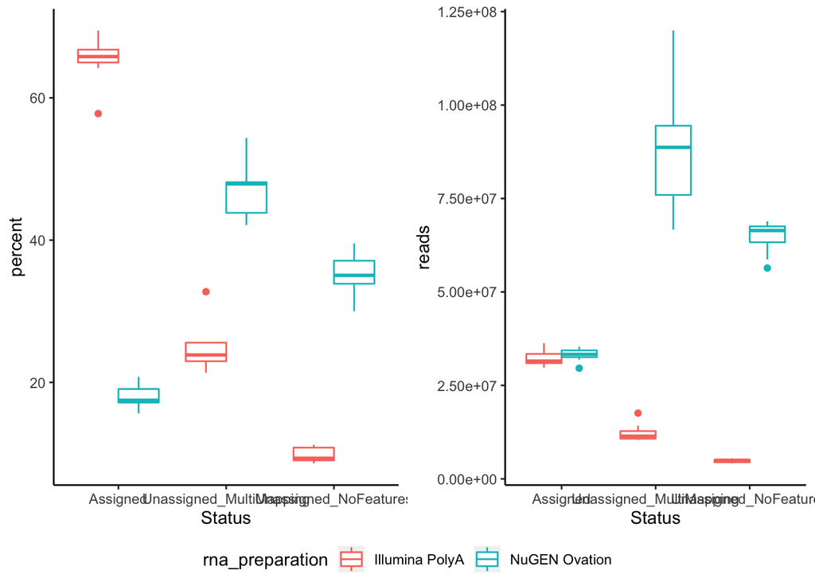

*Table2. Summary of readscount by mapping status and librarly prep method*

| Status | rna_preparation | ave_read | sd_read | mean_percent_reads |
| --- | --- | --- | --- | --- |
| Assigned | Illumina PolyA | 32302702 | 2189463 | 65.41 |
| Assigned | NuGEN Ovation | 33137180 | 1802351 | 17.99 |
| Unassigned_MultiMapping | Illumina PolyA | 12348606 | 2466827 | 24.83 |
| Unassigned_MultiMapping | NuGEN Ovation | 87826924 | 16694976 | 46.98 |
| Unassigned_NoFeatures | Illumina PolyA | 4814747 | 495280 | 9.76 |
| Unassigned_NoFeatures | NuGEN Ovation | 64638594 | 4580144 | 35.03 |

```
## [1] "Intercept"
## [2] "involution_Yes_vs_No"
## [3] "librarymethod_NuGEN.Ovation_vs_Illumina.PolyA"
## [4] "involutionYes.librarymethodNuGEN.Ovation"
```

```
##
## out of 22500 with nonzero total read count
## adjusted p-value < 0.05
## LFC > 0 (up)       : 1, 0.0044%
## LFC < 0 (down)     : 4, 0.018%
## outliers [1]       : 1029, 4.6%
## low counts [2]     : 0, 0%
## (mean count < 0)
## [1] see 'cooksCutoff' argument of ?results
## [2] see 'independentFiltering' argument of ?results
```

```
##
## FALSE  TRUE
## 21466     5
```

```
##
## out of 22500 with nonzero total read count
## adjusted p-value < 0.05
## LFC > 0 (up)       : 3671, 16%
## LFC < 0 (down)     : 4811, 21%
## outliers [1]       : 1029, 4.6%
## low counts [2]     : 3443, 15%
## (mean count < 1)
## [1] see 'cooksCutoff' argument of ?results
## [2] see 'independentFiltering' argument of ?results
```

```
##
## FALSE  TRUE
##  9546  8482
```

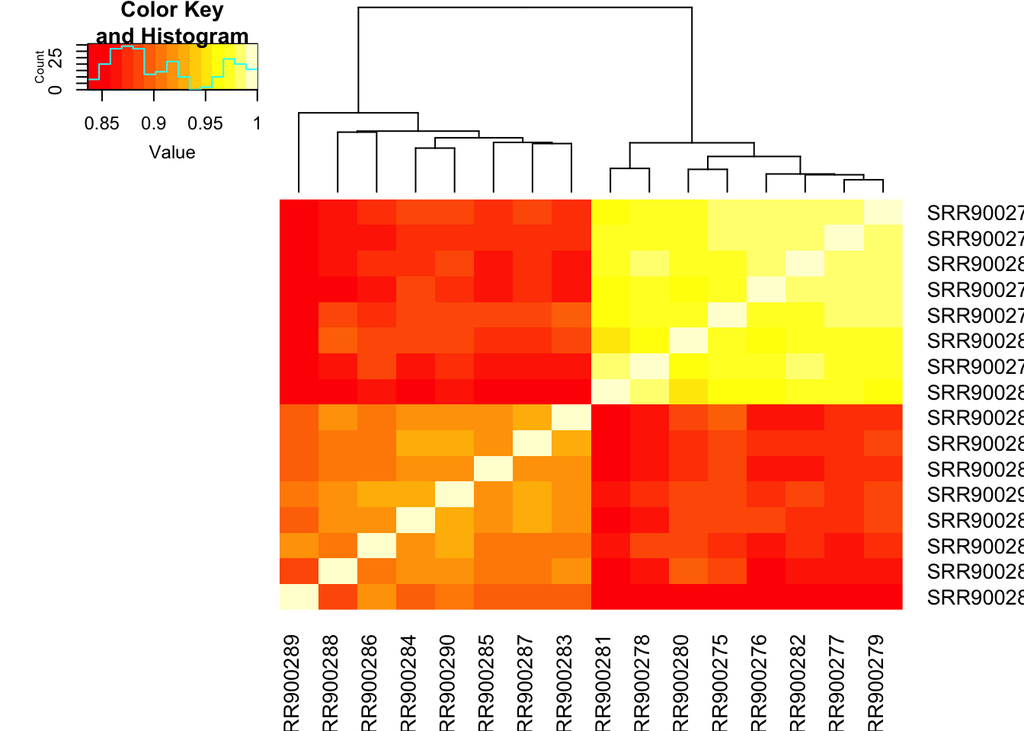

```
##
## out of 21580 with nonzero total read count
## adjusted p-value < 0.05
## LFC > 0 (up)       : 20, 0.093%
## LFC < 0 (down)     : 91, 0.42%
## outliers [1]       : 191, 0.89%
## low counts [2]     : 4939, 23%
## (mean count < 4)
## [1] see 'cooksCutoff' argument of ?results
## [2] see 'independentFiltering' argument of ?results
```

```
##
## FALSE  TRUE
## 16339   111
```

In DESeq analysis of readscount poly_a protocol data, using contrast fomular ~ condition, out of 21580 nonzero total read count, 111 with ajusted p-value < 0.05; Out of 19449 nonzero total read count in NuGEN protocal data, 165 with ajusted p-value < 0.05, with 21 commenly detected genes. Pearson correlation of the log2FoldChange between 2 conditions between the two library preparation protocols is 0.496.

```
##
## out of 19449 with nonzero total read count
## adjusted p-value < 0.05
## LFC > 0 (up)       : 51, 0.26%
## LFC < 0 (down)     : 114, 0.59%
## outliers [1]       : 1842, 9.5%
## low counts [2]     : 3821, 20%
## (mean count < 6)
## [1] see 'cooksCutoff' argument of ?results
## [2] see 'independentFiltering' argument of ?results
```

```
##
## FALSE  TRUE
## 13621   165
```

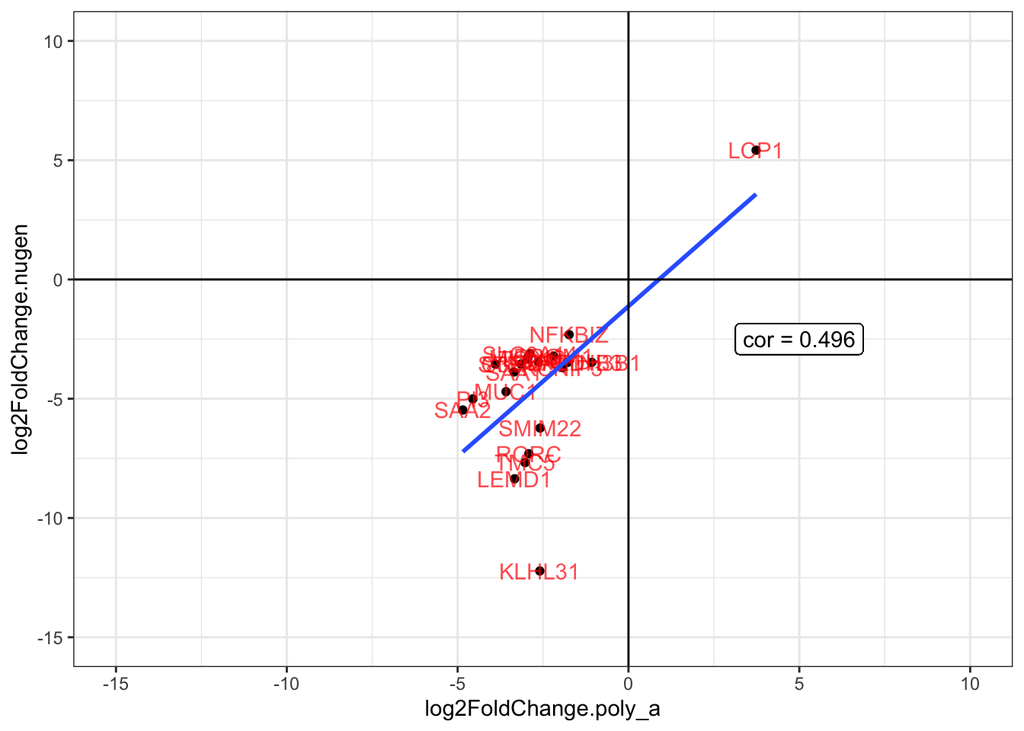

### DEG analysis in poly-a library method:

Log Fold Change of DEGs with ajusted p-value < 0.05 is plotted by Mean of Normalized Counts, genes with more than 2 fold change are highlighted in red. Mean of Normalized Counts of those DEGs are also plotted in heatmap.

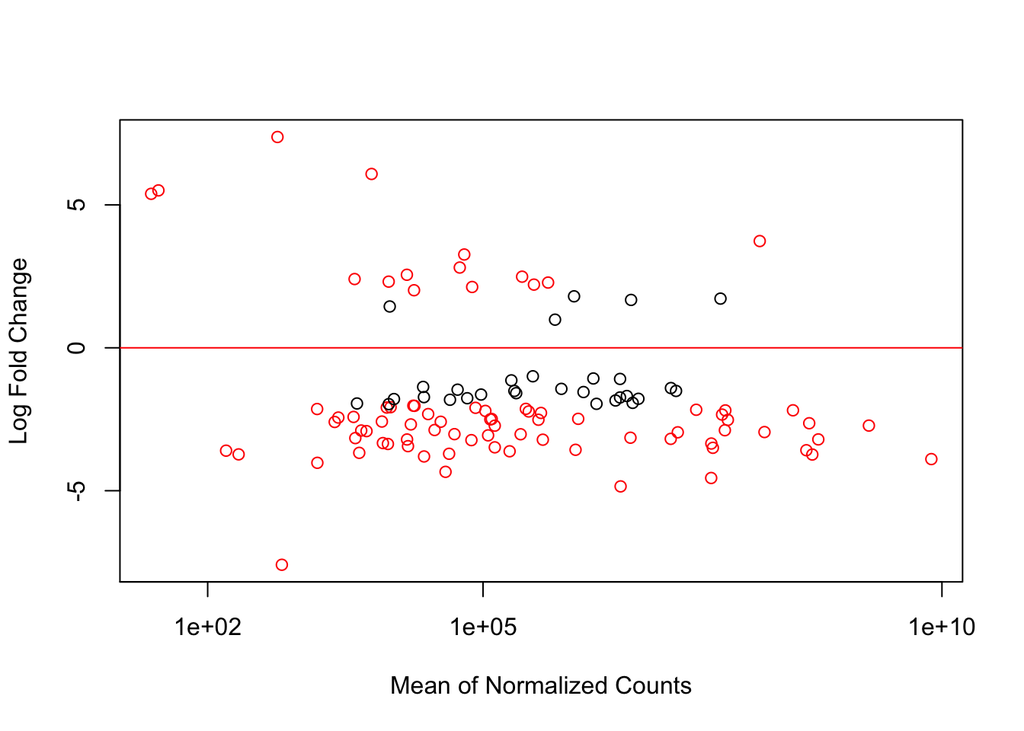

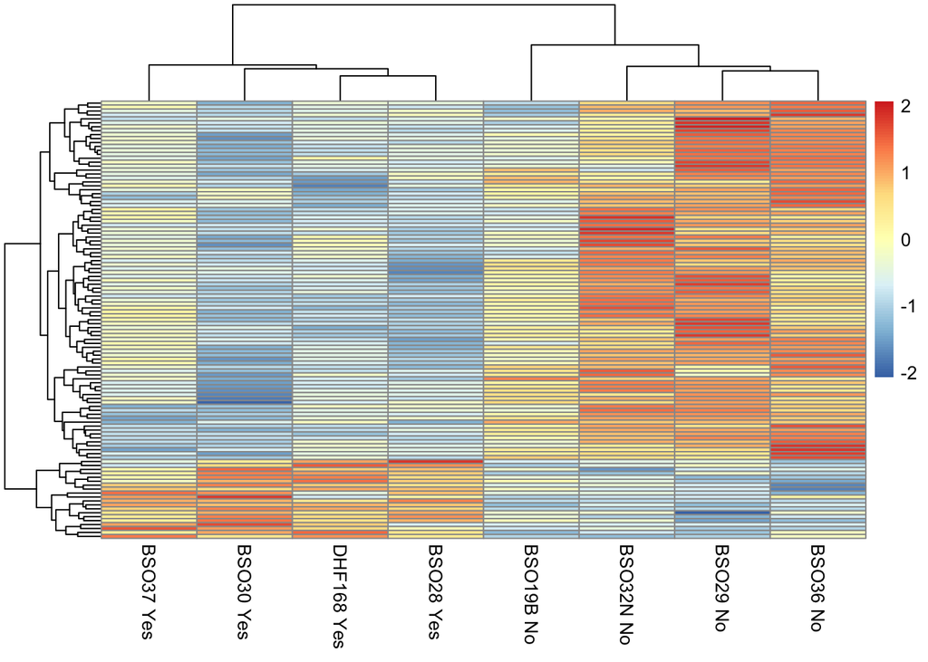

To explore the involution risk factor in genes differencial expression and their functional characteristics, Gene Ontology Term Enrichment Analysis is performed. 145 DEGs showed adjusted over_represented_pvalue < 0.05, treeplot is showed below.

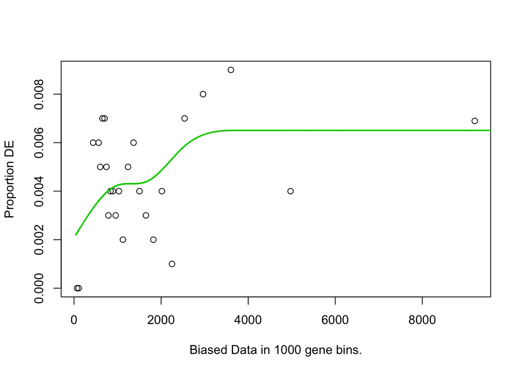

```
## Note: tmPlot deprecated as of version 2.0. Please use treemap instead.
```

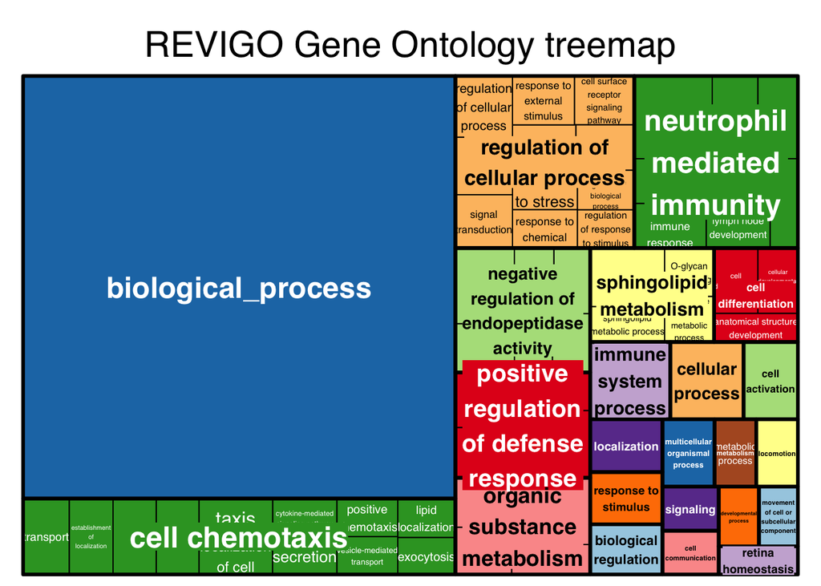

### Appendex:

Record:  
Genome:  
http://hgdownload.soe.ucsc.edu/goldenPath/hg38/bigZips/hg38.2bit  
Annotation:  
http://hgdownload.soe.ucsc.edu/goldenPath/hg38/bigZips/genes/  
hg38.refGene.gtf.gz 10-Jan-2020 09:33 23M  
hg38.trf.bed.gz - Tandem Repeats Finder locations, filtered to keep repeats with period less than or equal to 12, and translated into UCSC’s BED format. genomeGenerate: –sjdbOverhang 99  
alignReads: –alignIntronMin 20 –alignIntronMax 1000000 –twopassMode Basic  
# ENCODE options default for human  
#About 5.24% of introns are more than 200,000 bp and less than 10% of introns are more than 11,000 bp in length. Also, < 0.01% of the introns are < 20 bp in length –M.K. Sakharkar et al. / Distributions of Exons and Introns in the Human Genome

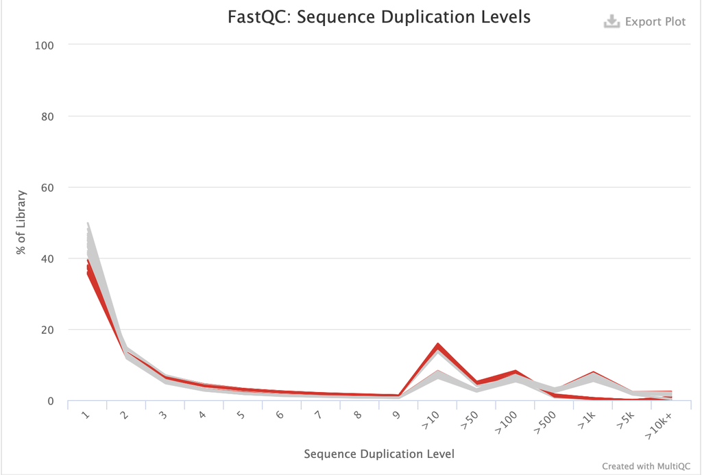

```r
#!/bin/bash
#SBATCH --nodes=1
#SBATCH --ntasks=1 --cpus-per-task=16
#SBATCH --job-name=qc_bash
#SBATCH --time=7-00:00:00
#SBATCH --mem=50G
#SBATCH --error=/athena/angsd/scratch/jiq4001/error
spack load fastqc
spack load -r trimgalore
spack load -r py-multiqc

# set current work dir
cwd=/athena/angsd/scratch/jiq4001/Pj

mkdir ${cwd}/QC
mkdir ${cwd}/QC/non_trimed
#mkdir ${cwd}/trimed
#mkdir ${cwd}/QC/trimed
mkdir ${cwd}/multi_qc

input_dir=${cwd}/test
qc_dir=${cwd}/QC/non_trimed
#trim_dir=${cwd}/trimed
#qc_trim_dir=${cwd}/QC_trimed
multi_qc=${cwd}/multi_qc

for file in $(ls ${input_dir} | cut -b -9 | uniq -d)
do
    fastqc ${input_dir}/${file}_1.fastq.gz -o ${qc_dir} -t 16 --extract
    fastqc ${input_dir}/${file}_2.fastq.gz -o ${qc_dir} -t 16 --extract

    #trim_galore --illumina --stringency 5 --length 30 --paired -o ${trim_dir} ${input_dir}/${file}_1.fastq.gz ${input_dir}/${file}_2.fastq.gz

    #fastqc ${trim_dir}/${file}_1_val_1.fq.gz -o ${qc_trim_dir} -t 16 --extract
    #fastqc ${trim_dir}/${file}_2_val_2.fq.gz -o ${qc_trim_dir} -t 16 --extract
done

cd ${multi_qc}
multiqc ${qc_dir}
```

,

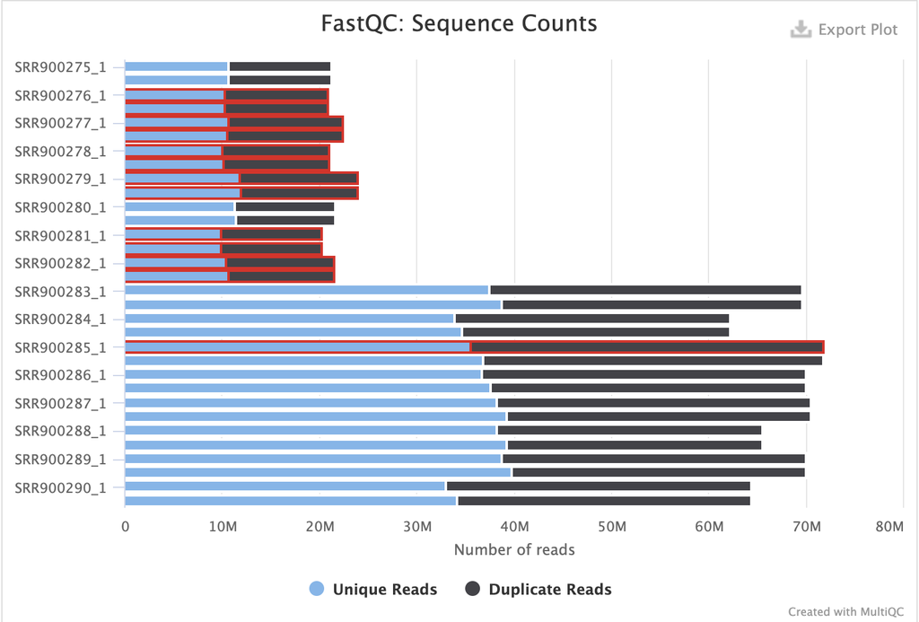

```r
#!/bin/bash
#SBATCH --nodes=1
#SBATCH --ntasks=1 --cpus-per-task=16
#SBATCH --job-name=idx
#SBATCH --time=7-00:00:00
#SBATCH --mem=80G
#SBATCH --error=/athena/angsd/scratch/jiq4001/error
#SBATCH --out=/athena/angsd/scratch/jiq4001/out

spack load star@2.7.0e

cwd=/athena/angsd/scratch/jiq4001/Pj

mkdir ${cwd}/Star_align
sample_dir=${cwd}/test
star_align=${cwd}/Star_align

for file in $(ls ${sample_dir} | cut -b -9 | uniq -d)
do
STAR --runMode alignReads \
--runThreadN 16 \
--genomeDir ${cwd}/hg38_STARindex \
--readFilesIn ${sample_dir}/${file}_1.fastq.gz ${sample_dir}/${file}_2.fastq.gz \
--outFileNamePrefix ${star_align}/${file}. \
--outSAMattributes NH HI AS nM MD \
--twopassMode Basic \
--readFilesCommand zcat \
--outSAMtype BAM SortedByCoordinate
done
```

Alignment QC

```r
[jiq4001@farina Star_align]$spack load samtools@1.9%gcc@6.3.0

# index aligned file
[jiq4001@farina Star_align]$ for file in $(ls | egrep ".*.bam"); do  samtools index ${file}; done

#  flagstat aligned file
[jiq4001@farina Star_align]$ for file in $(ls | egrep ".*.bam$"); do samtools flagstat ${file} >> ${file}_flagstat_out; done

#!/bin/bash
#SBATCH --nodes=1
#SBATCH --ntasks=1 --cpus-per-task=16
#SBATCH --job-name=idx
#SBATCH --time=7-00:00:00
#SBATCH --mem=60G
#SBATCH --error=/athena/angsd/scratch/jiq4001/error
#SBATCH --out=/athena/angsd/scratch/jiq4001/out

cwd=/athena/angsd/scratch/jiq4001/Pj

spack load -r py-rseqc

for SAMPLE in $(ls ${cwd}/Star_align | egrep ".*.bam$")
do
read_distribution.py -i ${cwd}/Star_align/${SAMPLE} -r ${cwd}/hg38.trf.bed > ${cwd}/QC_Star_align/${SAMPLE}.read_distribution.out

geneBody_coverage.py -i ${cwd}/Star_align/${SAMPLE} -r ${cwd}/hg38.trf.bed -o ${cwd}/QC_Star_align/${SAMPLE}.geneBody_coverage.out

mismatch_profile.py -i ${cwd}/Star_align/${SAMPLE} -r ${cwd}/hg38.trf.bed -o ${cwd}/QC_Star_align/${SAMPLE}.mismatch_profile.out

done

## run multiqc .....
```

*Figure1. Gene Body Coverage*

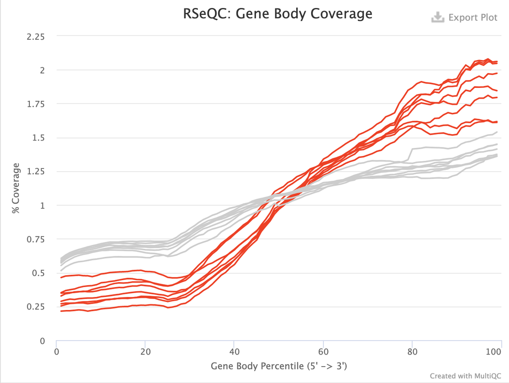

It appears both sequencing experiments with either library preparation methods are not able to get ideal sufficient coverage at 5’end, though the aim was not to identify low expression genes.

Reads count

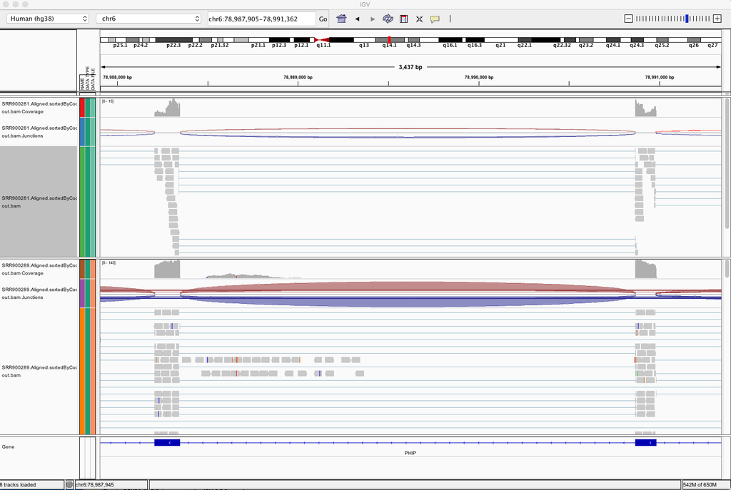

IGV

```r
#SBATCH --ntasks=1 --cpus-per-task=16
#SBATCH --job-name=idx
#SBATCH --time=7-00:00:00
#SBATCH --mem=80G
#SBATCH --error=/athena/angsd/scratch/jiq4001/error
#SBATCH --out=/athena/angsd/scratch/jiq4001/out

spack load subread

#mkdir reads_count
cwd=/athena/angsd/scratch/jiq4001/Pj
sample_dir=${cwd}/Star_align
out_dir=${cwd}/reads_count


featureCounts -a ${cwd}/hg38.refGene.gtf \
-o ${out_dir}/featCounts_all.txt \
--minOverlap 25 \
-t "exon" \
-g "gene_id" \
--primary \
--tmpDir '/scratchLocal' \
${sample_dir}/*.bam
```